# Examen Final

*175904 - Jorge III Altamirano Astorga*

*177508 - Uriel Miranda Miñón*

## Load

Se cargan los datos originales en formato JSON y se separan datos de entrenamiento y validación; existe además forma de datos de prueba adicionales en la prueba de Kaggle. :-)

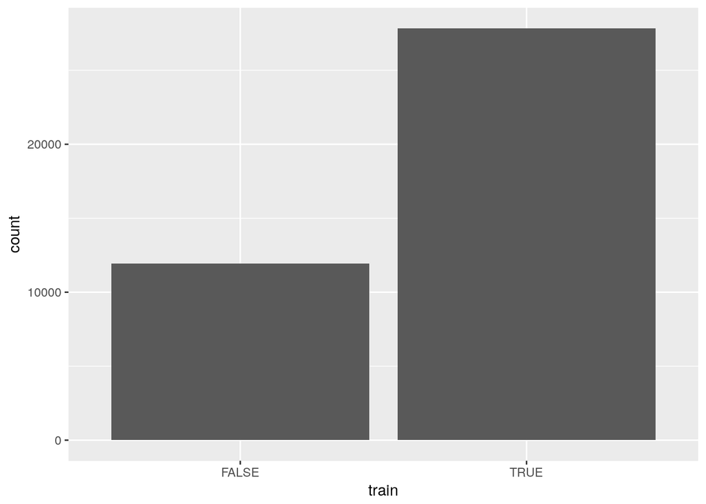

```r
set.seed(175904)
train_raw <- fromJSON("data/train.json")
train_raw <- train_raw %>% as.data.frame
train_raw$train <- F
train_raw[sample(nrow(train_raw), nrow(train_raw)*.7, replace = F), 4] <- T
train <- train_raw[train_raw$train == T,1:3]
valid <- train_raw[train_raw$train == F,1:3]
train_2 <- train
valid_2 <- valid

ggplot(train_raw, aes(x=train)) +
  geom_histogram(stat="count")
```

## Cleaning

Se limpian los datos de palabras que consideramos que no añaden valor a la predicción. De los cuales consideramos

- Gentilicios: mexican, italian, greek, parma, …
- Onzas, small, warm, hot, rich, …
- Formas: minced, cubed, smoked, unflavored, unsalted, light, heavy, low-fat, …
- Variantes: toasted, young, fresh, …
- Marcas: Oscar Mayer, Kraft, Velveeta, Everglades, …

Así mismo se condensaron los datos por palabras clave, los cuales consideramos ordinales en importancia:

1. Vegetales: beans, lettuce, potato(es), lemon, …
2. Derivados animales: tipos de queso, tipos de embutido, huevos, leche de coco, crema, …
3. Proteínas: stock, beef, pork, chicken, oyster
4. Especias: sal, curry, ajo, …

Ejemplo de condensación de datos:

- Lemon zest -> lemon
- roasted beef -> beef
- chicken broth -> chicken

Todo esto derivado de estudiar el dataset con el fin de reducir el número de variables.

### Limpieza

```r
unimportant_words <- "(^a taste of|any|low-fat|low ?salt|all|powder|baby|bertolli|boiled|boiling|bone in|whole|boneless|bottled|sauvignon|california|campbells condensed|canned|chopped|flavored carbonated beverage|cold|condensed|cooked|cooking|cereal|lowfat|frosting|spread|soften|with chives.*|ic peach| of .*|creamed|creamy| mexican.?|crushed|crystal farms|shredded|crystallized|crystal hot|cubed|curly|curlyleaf|jelly|dessert mix|sauce mix|mix|dark|dellallo|deepfried|deep fried|diced|diet|tortilla chips||domino|dried|minced|dry|earth balance|elmlea|^english|evaporated|everglades|extra fine|extra firm|extra large|extra\\s?lean|extra light|extra sharp|extra\\s?virgin|extra wide|^fat|fat\\s?free|fat skimmed|fatfree?|fattrimmed|fine|firm|firmly packed|flat |^flavored|terrine|food|free\\s?range|^french|^fresh| root|^fresno|^fried|^frozen|^fuji|full\\s?fat|gluten\\s?free|s milk |^gold|golden|gourmet|graham|granulated|grassfed|grated|grating|gravenstein|great|greater|style|green|grilled|grill|ground|half|heavy|heinz|hellmanns?|of the woods|herbed |herdez|hidden valley|homemade|^hot |hot smoked|hot spanish|^hungarian|hurst|i cantbelieve? its? not butter|imitation|imperial sugar light brown|instant |^irish|^italian|italianstyle|^japanese |jimmy dean|johnsonville|jose cuervo|jumbo|kikkoman|knorr|knudsen|kraft|mexican style|kraft zesty|slim cut|sun dried|shredded|la victoria|land o lakes|^large|^lean|leftover|leg of|zest|less sodium|lesser|leaves|^light|cook and drain|lipton|liquid |^lite|^long |loosely packed fresh|low fat|lowfat|^low sodium|lower sodium|lowfat|baked|\\sdeli|firm silken|styl|lowsodium|and cheese dinner|madagascar bourbon|extract|mccormick|^medium|uncook|uncooked|merguez|^mexican|minced|mini|mini|mixed|mixture|mizkan|^mms|mrs dash|natural|^nido|non dairy|non fat|non stick|nondairy|nonfat|frozen|nonhydrogenated|nosaltadded|old el paso|old|old\\s?fashioned|cooking spray|flavored|^organic|oscar mayer|other|oven\\s?ready|flavor|flavour|paella|reggiano|peeled|^petite|pillsbury|powdered|prepared|preserv|preserved|progresso|\\sdi\\sparma|pt|pte|puff|puffed|pure|quickcooking|quick|cooking|raw|red|reduced\\sfat|reduced\\ssodium|reduced\\ssugar|reducedfat|reducedsodium|reducedsugar|refrigerated|regular|rich|roasted|roast|roasting|robert mondavi|salt free seasoning|salt free chili powder|salt free cajun creole seasoning|salt free southwest chipotle seasoning|salt free herb seasoning|salt free chili powder|salted|saltines?|saltpeper|san marazano|sargento|links|casings|savoy|seafood|seasoned|seasoning|seedless|self ?ra?ising|shredded|single|simple|skinless|sliced|small|smoked|sodium free|sodium reduced|soft|softened|solid|southern comfort.*|southwest|sparkling|spicy|splenda.*|split|spring water|^strip|superfine|sweetened|taco bell.*|into serving pieces|to\\s+lb|toasted|uncle bens|^uncook|^uncooked|unflavou?red|unsweetened|white|wholesome sweeteners|wholemilk|wide|^wild|^winter|wish\\s?bone|yellow|young|zesty|part ?skim|italian|all ?purpose|puree|juice|aged|tuna in water|liqueur|liquor|^asian|and .*|yoplait|greek|fresh|spray|hot water|warm water|crumbles|freshly|flakes?|unsalt|unsalted|wedges?|plain)(\\s|$)"
popular_words <- function(a){
  a <- gsub("(.*)(beans?|lettuce|olives?|tabasco|potato(es)?|cilantro|wheat|shiitake|lemon|chives?|tomato(es)?|cabbage|peanut|yogh?o?urt|rice|onions?|ginger|sesame|jalapeno|stock|bacon|monterey_jack|vinegar|sausages?|mozz?arell?a|monterey_jack|feta|ricotta|dijon|masala|eggs?|coconut_milk|cheddar|dijon|parmesan|sour_(crema|cream)|steak|pork|beef|chicken|oyster|garlic|salt|curry).*", "\\2", a)
}

#limpiar datos de ingredientes
train_2$ingredients <- sapply(1:nrow(train), function(x) {
  train[x,3] %>%
    unlist %>%
    tolower %>%
    gsub("\\([^)]*\\)", "", ., perl = T, ignore.case = T) %>%
    gsub("[^ a-z]", "", ., perl = T, ignore.case = T) %>%
    gsub("^\\s+", " ", ., perl = T, ignore.case = T) %>%
    gsub(unimportant_words, " ", ., perl = T, ignore.case = T) %>%
    gsub("\\s+", " ", ., perl = T, ignore.case = T) %>%
    unique %>%
    trimws %>%
    gsub("\\s", "_", ., perl = T, ignore.case = T) %>%
    popular_words
})

#limpiar los datos de validación
valid_2$ingredients <- sapply(1:nrow(valid), function(x) {
  valid[x,3] %>%
    unlist %>%
    tolower %>%
    gsub("\\([^)]*\\)", "", ., perl = T, ignore.case = T) %>%
    gsub("[^ a-z]", "", ., perl = T, ignore.case = T) %>%
    gsub("^\\s+", " ", ., perl = T, ignore.case = T) %>%
    gsub(unimportant_words, " ", ., perl = T, ignore.case = T) %>%
    gsub("\\s+", " ", ., perl = T, ignore.case = T) %>%
    unique %>%
    trimws %>%
    gsub("\\s", "_", ., perl = T, ignore.case = T) %>%
    popular_words
})

train_2$cuisine <- train_2$cuisine %>% as.factor
valid$cuisine <- valid$cuisine %>% as.factor

ingredients <- train_2$ingredients %>%
  unlist
ingredients <- ingredients[which(!grepl(pattern = "^$", x = ingredients))] #%>%
#    unique
ingredients %>% head(n=10)
```

```
##  [1] "lettuce"  "olives"   "tomatoes" "garlic"   "pepper"   "onion"
##  [7] "beans"    "feta"     "flour"    "pepper"
```

```r
ingredients_df <- as.data.frame(ingredients, stringsAsFactors = F) %>%
  group_by(ingredients)

ingredients_count <- ingredients_df %>%
  plyr::count(.) %>%
  arrange(freq)
ingredients_count$id <- 1:nrow(ingredients_count)
head(ingredients_count)
```

|  | ingredients | freq | id |
| --- | --- | --- | --- |
| 1 | abbamele | 1 | 1 |
| 2 | absinthe | 1 | 2 |
| 3 | agar_agar | 1 | 3 |
| 4 | agave_tequila | 1 | 4 |
| 5 | alaskan_king_crab_legs | 1 | 5 |
| 6 | alcohol | 1 | 6 |

```r
tail(ingredients_count)
```

|  | ingredients | freq | id |
| --- | --- | --- | --- |
| 3309 | pepper | 6792 | 3309 |
| 3310 | chicken | 7056 | 3310 |
| 3311 | olive | 7633 | 3311 |
| 3312 | onions | 8606 | 3312 |
| 3313 | garlic | 12948 | 3313 |
| 3314 | salt | 16713 | 3314 |

```r
ingredients_top <- ingredients_count %>%
  filter(freq > 150) %>%
  arrange(desc(freq)) %>%
  select(ingredients)
```

### Variables

```r
train_3 <- train_2[,1:2]
valid_3 <- valid_2[,1:2]
#crea las columnas
train_3[, ingredients_top %>% unlist] <- 0
valid_3[, ingredients_top %>% unlist] <- 0
#llena las columnas
for(i in 1:nrow(train_3)){
  train_3[i, which(names(train_3) %in% (train_2[i,]$ingredients %>% unlist))] <- 1
}
for(i in 1:nrow(valid_3)){
  valid_3[i, which(names(valid_3) %in% (valid_2[i,]$ingredients %>% unlist))] <- 1
}
rm(i)
saveRDS(train_2, "data/train_2.rds")
saveRDS(train_3, "data/train_3.rds")
saveRDS(valid_2, "data/valid_2.rds")
saveRDS(valid_3, "data/valid_3.rds")
# train_2 <- readRDS("data/train_2.rds")
# train_3 <- readRDS("data/train_3.rds")
# valid_2 <- readRDS("data/valid_2.rds")
# valid_3 <- readRDS("data/valid_3.rds")
train_3 %>%
  select(id,cuisine,garlic,salt,pepper) %>%
  head(n=5)
```

|  | id | cuisine | garlic | salt | pepper |
| --- | --- | --- | --- | --- | --- |
| 1 | 10259 | greek | 1 | 0 | 1 |
| 2 | 25693 | southern_us | 0 | 1 | 1 |
| 5 | 13162 | indian | 1 | 1 | 0 |
| 6 | 6602 | jamaican | 0 | 1 | 0 |
| 9 | 16903 | mexican | 0 | 1 | 0 |

```r
valid_3 %>%
  select(id,cuisine,garlic,salt,pepper) %>%
  head(n=5)
```

|  | id | cuisine | garlic | salt | pepper |
| --- | --- | --- | --- | --- | --- |
| 3 | 20130 | filipino | 1 | 1 | 1 |
| 4 | 22213 | indian | 0 | 1 | 0 |
| 7 | 42779 | spanish | 1 | 1 | 1 |
| 8 | 3735 | italian | 0 | 0 | 0 |
| 12 | 45887 | chinese | 1 | 0 | 1 |

## EDA

### Frecuencias de ingredientes

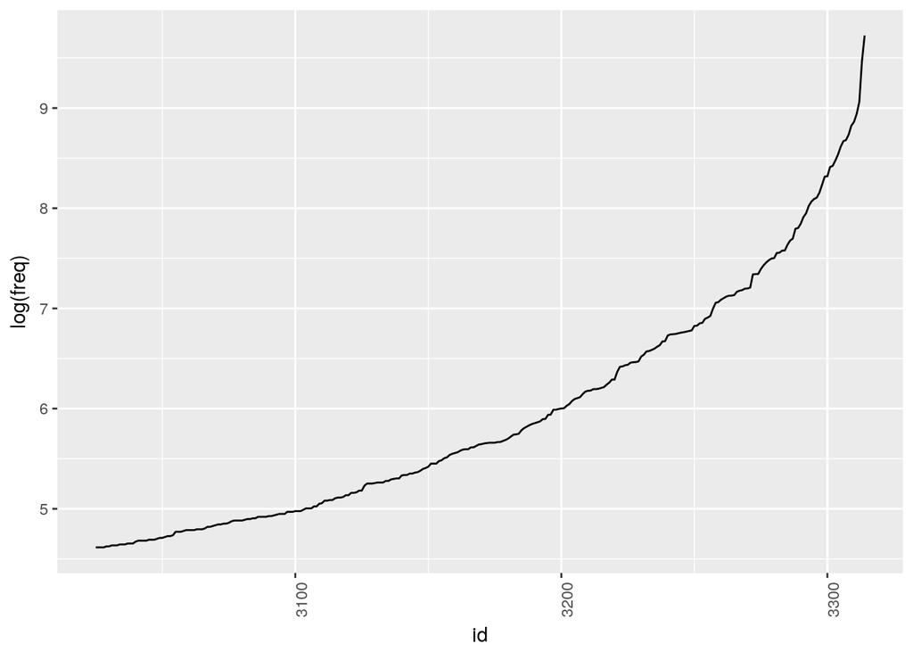

```r
ggplot(ingredients_count %>% filter(freq > 100),aes(x=id, y=log(freq)))+geom_line() +
  theme(axis.text.x = element_text(angle = 90, hjust = 1))
```

### Número de ingredientes por tipo de cocina

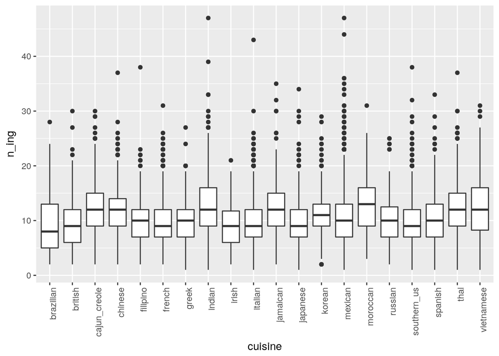

```r
n_ing <- train_2$ingredients
# a_ing <-
train_2$n_ing <- sapply(1:length(n_ing),function(i){length(n_ing[[i]])})
ggplot(train_2 , aes(x=cuisine,y=n_ing)) +
  geom_boxplot() +
  theme(axis.text.x=element_text(angle=90,hjust=1))
```

```r
rm(n_ing)
```

### Stats

```r
data.frame( Cuisine = unique(train_2$cuisine),
                       Mean = aggregate(train_2$n_ing, list(train_2$cuisine), mean)[,2],
                       SD = aggregate(train_2$n_ing, list(train_2$cuisine), sd)[,2],
                       Min = aggregate(train_2$n_ing, list(train_2$cuisine), min)[,2],
                       Max = aggregate(train_2$n_ing, list(train_2$cuisine), max)[,2])
```

| Cuisine | Mean | SD | Min | Max |
| --- | --- | --- | --- | --- |
| greek | 9.234568 | 4.820677 | 2 | 28 |
| southern_us | 9.427046 | 4.072321 | 2 | 30 |
| indian | 12.379216 | 4.505699 | 2 | 30 |
| jamaican | 11.844002 | 3.933979 | 2 | 37 |
| mexican | 10.025097 | 3.891834 | 2 | 38 |
| italian | 9.705372 | 4.139598 | 2 | 31 |
| british | 10.059737 | 3.654160 | 1 | 27 |
| thai | 12.662216 | 4.971382 | 1 | 47 |
| chinese | 9.085837 | 3.564028 | 2 | 21 |
| cajun_creole | 9.838300 | 3.718990 | 1 | 43 |

[output cut: 10 more lines]

### Frecuencias de ingredientes por cocina

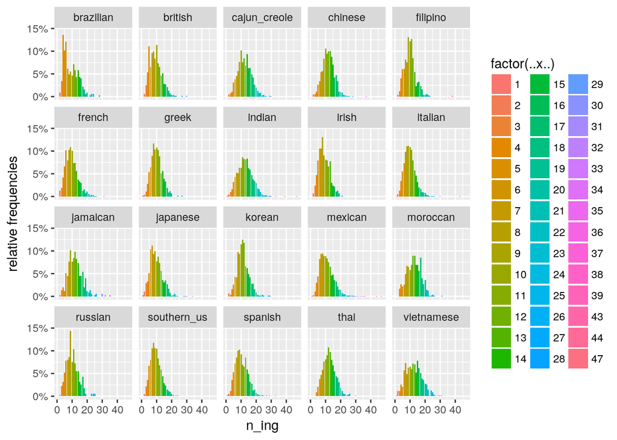

```r
ggplot(train_2, aes(n_ing, group = cuisine)) +
    geom_bar(aes(y = ..prop.., fill = factor(..x..)), stat="count") +
    scale_y_continuous(labels=scales::percent) +
    ylab("relative frequencies") +
    facet_wrap(~cuisine)
```

### Casos por cocina

Vemos que la cocina mexicana es una cocina muy popular. :-)

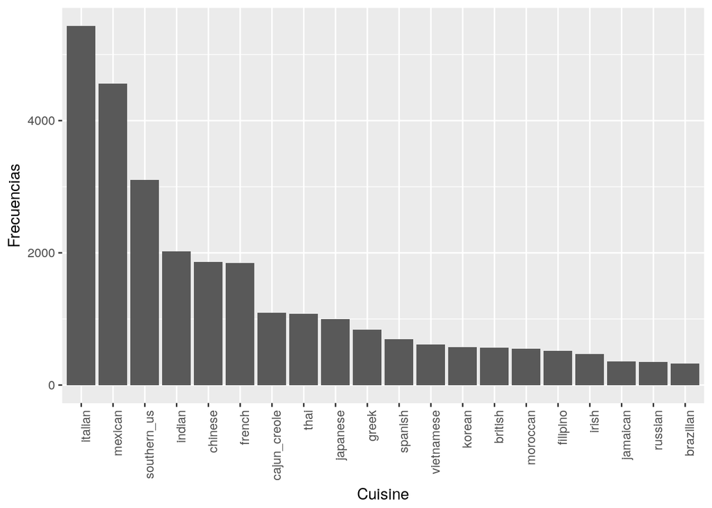

```r
ggplot((train_2$cuisine %>% plyr::count()), aes(x = reorder(x, -freq), y = freq)) +
  geom_bar(stat = "identity") +
  xlab("Cuisine") +
  ylab("Frecuencias") +
  theme(axis.text.x=element_text(angle=90,hjust=1))
```

## Models

### Lineal

```r
# lm <- glmnet(x = train_3[,3:100] %>% as.matrix,
#                 y = train_3$cuisine,
#                 family = "multinomial",
#                 alpha = 1)
```

#### Entrenamiento

```r
# train_3$lm <- predict(arbol_grande, newdata = train_3[,3:210], type="class")
# train_3 %>% mutate(lm_pred = (cuisine == lm)) %>% select(lm_pred) %>% summary
# train_3 %>% select(cuisine, lm)
```

#### Validación

```r
# valid_3$lm <- predict(lm, newdata = valid_3[,3:210], type="class")
# valid_3 %>% mutate(lm_pred = (cuisine == lm)) %>% select(lm_pred) %>% summary
# valid_3 %>% select(cuisine, lm)
```

### Árbol

Predice súmamente mal, incluso con el conjunto de entrenamiento. Debido a esto, exploramos otros algoritmos.

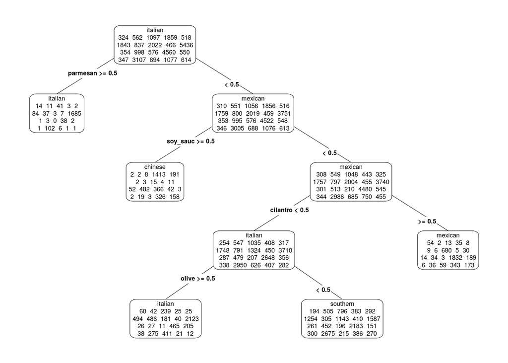

```r
arbol_grande <- rpart(cuisine ~ ., data= train_3[,-1], cp=0)
prp(prune(arbol_grande, cp=0.03), type=4, extra=1, digits=3)
```

```r
train_3$arbol <- predict(arbol_grande, newdata = train_3[,3:210], type="class")
train_3 %>% mutate(arbol_pred = (cuisine == arbol)) %>% select(arbol_pred) %>% summary
```

```
##  arbol_pred
##  Mode :logical
##  FALSE:10294
##  TRUE :17547
```

```r
train_3 %>% select(cuisine, arbol)
```

|  | cuisine | arbol |
| --- | --- | --- |
| 1 | greek | greek |
| 2 | southern_us | southern_us |
| 5 | indian | indian |
| 6 | jamaican | southern_us |
| 9 | mexican | mexican |
| 10 | italian | italian |
| 11 | italian | mexican |
| 14 | mexican | mexican |
| 15 | italian | italian |
| 16 | indian | indian |

[output cut: 9990 more lines]

### Bosques Aleatorios

```r
bosque <- foreach(ntree=rep(150, 3), .combine=combine, .multicombine=TRUE,
              .packages='randomForest') %dopar% {
    randomForest(cuisine ~ . , data = train_3[,2:210], ntree=ntree)
              }
```

#### Entrenamiento

```r
train_3$bosque <- predict(bosque, newdata = train_3[,3:210], type="class")
train_3 %>% mutate(bosque_pred = (cuisine == bosque)) %>% select(bosque_pred) %>% summary
```

```
##  bosque_pred
##  Mode :logical
##  FALSE:2644
##  TRUE :25197
```

```r
train_3 %>% select(cuisine, bosque)
```

|  | cuisine | bosque |
| --- | --- | --- |
| 1 | greek | greek |
| 2 | southern_us | southern_us |
| 5 | indian | indian |
| 6 | jamaican | southern_us |
| 9 | mexican | mexican |
| 10 | italian | italian |
| 11 | italian | italian |
| 14 | mexican | mexican |
| 15 | italian | italian |
| 16 | indian | indian |

[output cut: 9990 more lines]

#### Validación

```r
valid_3$bosque <- predict(bosque, newdata = valid_3[,3:210], type="class")
valid_3 %>% mutate(bosque_pred = (cuisine == bosque)) %>% select(bosque_pred) %>% summary
```

```
##  bosque_pred
##  Mode :logical
##  FALSE:3592
##  TRUE :8341
```

```r
valid_3 %>% select(cuisine, bosque)
```

|  | cuisine | bosque |
| --- | --- | --- |
| 3 | filipino | chinese |
| 4 | indian | indian |
| 7 | spanish | mexican |
| 8 | italian | italian |
| 12 | chinese | chinese |
| 13 | italian | italian |
| 18 | italian | italian |
| 20 | vietnamese | chinese |
| 23 | southern_us | southern_us |
| 26 | chinese | chinese |

[output cut: 9990 more lines]

### SVM

```r
set.seed(175904)
svm <- parallelSVM(cuisine ~ . , data = train_3[,2:210],
            numberCores = detectCores()-1,
            samplingSize = 0.2,
            na.action = na.omit,
            scale = TRUE)
```

#### Entrenamiento

```r
train_3$svm <- predict(svm, newdata = train_3[,3:210], type="class")
train_3 %>% mutate(svm_pred = (cuisine == svm)) %>% select(svm_pred) %>% summary
```

```
##   svm_pred
##  Mode :logical
##  FALSE:8762
##  TRUE :19079
```

```r
train_3 %>% select(cuisine, svm)
```

|  | cuisine | svm |
| --- | --- | --- |
| 1 | greek | greek |
| 2 | southern_us | southern_us |
| 5 | indian | indian |
| 6 | jamaican | southern_us |
| 9 | mexican | mexican |
| 10 | italian | italian |
| 11 | italian | italian |
| 14 | mexican | mexican |
| 15 | italian | italian |
| 16 | indian | indian |

[output cut: 9990 more lines]

#### Validación

```r
valid_3$svm <- predict(svm, newdata = valid_3[,3:210], type="class")
valid_3 %>% mutate(svm_pred = (cuisine == svm)) %>% select(svm_pred) %>% summary
```

```
##   svm_pred
##  Mode :logical
##  FALSE:4096
##  TRUE :7837
```

```r
valid_3 %>% select(cuisine, svm)
```

|  | cuisine | svm |
| --- | --- | --- |
| 3 | filipino | filipino |
| 4 | indian | italian |
| 7 | spanish | italian |
| 8 | italian | italian |
| 12 | chinese | chinese |
| 13 | italian | italian |
| 18 | italian | southern_us |
| 20 | vietnamese | chinese |
| 23 | southern_us | southern_us |
| 26 | chinese | chinese |

[output cut: 9990 more lines]

## Bibliografía

- [ParallelSVM](https://cran.r-project.org/web/packages/parallelSVM/parallelSVM.pdf)
- [doParallel](https://cran.r-project.org/web/packages/doParallel/vignettes/gettingstartedParallel.pdf)
- [StackOverflow: Speedup Random Forests](https://stackoverflow.com/questions/7830255/suggestions-for-speeding-up-random-forests/7831848#7831848)
- [StackOverflow: Parallelizing RF](https://stackoverflow.com/questions/37213279/parallelizing-random-forests)